# `RHugin` Install Instructions for Microsoft Windows

Last updated by Kjell Konis on 2017-02-02.

Read the *Preliminaries* section even if you already have R, Rtools, and the HUGIN Decision Engine installed. You probably will need to install the *Microsoft Visual C++ 2010 Redistributable Package (x64)*. These instructions have only been tested with 64 bit versions of R and the HDE running on Windows 10 (64 bit).

### Preliminaries

The `RHugin` package provides an R API for the HUGIN Decision Engine (HDE): both the HDE and R must be installed on the computer in order for the `RHugin` package to function.

#### Install HUGIN and the HUGIN Decision Engine (HDE)

The HUGIN Decision Engine is commercial software available from HUGIN EXPERT.

> http://www.hugin.com

The products *HUGIN Developer* (commercial use) and *HUGIN Researcher* (academic use) include the Hugin Decision Engine. The HDE is also included with the free demo *HUGIN Lite* (the only permitted use of the free demo is to evaluate HUGIN).

#### Install the Microsoft Visual C++ 2010 Redistributable Package (x64)

The dll that RHugin links to in the HDE was created with Microsoft Visual C++ 2010 and requires the runtime components for this compiler to be installed. These runtime components are provided in the package *Microsoft Visual C++ 2010 Redistributable Package (x64)* that should be downloaded directly from Microsoft.

> https://www.microsoft.com/en-us/download/details.aspx?id=14632

If installation fails, the most likely reason is that you already have these components installed (some manufacturers, e.g., Lenovo, preinstall these packages; others don’t). Read the message carefully.

#### Install R

R is available from the CRAN repository.

> https://cloud.r-project.org/

The installer for the most recent version of R can be found by following *Download R for Windows > base*.

#### Install Rtools

Since `RHugin` is distributed as a source package you will also need to install Rtools (the compilers, etc. used to build R). The Rtools installer can be found by following *Download R for Windows > Rtools*. The most recent version is at the top of the list.

Once these four pieces of software are installed, start R and proceed to the next section.

### RHugin Package Depedencies

The `RHugin` package has dependencies on the `graph` and `Rgraphviz` packages. These packages are part of Bioconductor and can be installed by running the following two R commands.

```r
source("https://bioconductor.org/biocLite.R")
biocLite(c("graph", "Rgraphviz"))
```

### Install the `RHugin` Package

Use the following R command to install the `RHugin` package from `RHugin`’s R-Forge repository.

```r
install.packages("RHugin", repos = "http://rhugin.r-forge.r-project.org",
                 type = "source", INSTALL_opts="--no-multiarch")
```

### Quick Test

To check that everything went as planned run the following code to plot one of the example networks provided by HUGIN.

```r
library(RHugin)
```

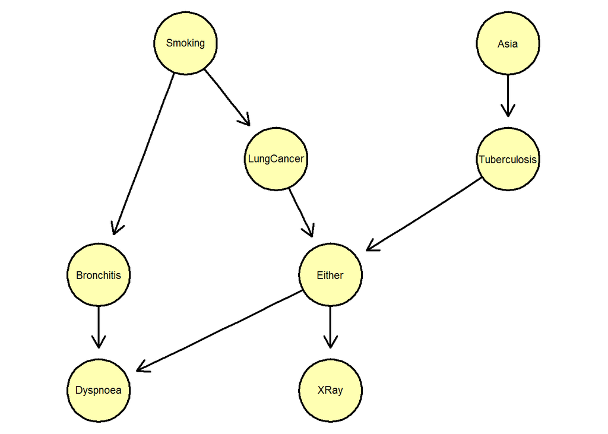

```r
demo("asia", echo = FALSE)
plot(asia)
```

Happy HUGINing with `RHugin`!

Copyright 2017 Kjell Konis